# Notebook

*Standard usage:*

- Requires Jupyter 3.0 and ipywidgets (type "pip install ipywidgets" in windows command line.)
- Copy this notebook to your desired location.
- Do not modify the first 4 cells in this notebook.
- Run the raw code toggle cell (code cell #1)
- Select a pkl with the "Get File Path" button. **It is recommended to have only one pkl file in a given folder!**
- Once the pkl file has been chosen, the notebook will run all the cells automatically.
- Adjust the parameters with the sliding bar to get desired results. **Make sure to hit the "submit changes and rerun below cells" button after each change.**
- Make sure to hit "save all" button when you are done. Standardized the results will be saved into the same folder containing the pkl file.

*Raw code toggle*

- If code is hidden and you don't see a button, click the hidden cell right below this cell and run it
- It's very thin and between this cell and the "Get File Path" cell, sorry for the inconvenience

```python
from IPython.display import Javascript,display
from corticalmapping.ipython_lizard.html_widgets import raw_code_toggle
raw_code_toggle()
display(Javascript("""var nb = IPython.notebook;
                      //var is_code_cell = (nb.get_selected_cell().cell_type == 'code')
                      //var curr_idx = (nb.get_selected_index() == 3);
                      nb.select(3);
                      nb.execute_cell();
                      """))
```

```python
from IPython.display import Javascript
from corticalmapping.ipython_lizard.ipython_filedialog import IPythonTkinterFileDialog
initial_dir = r"C:"

tkinter_file_dialog = IPythonTkinterFileDialog(initial_dir)
tkinter_file_dialog.execute_below = True
tkinter_file_dialog.show()
```

```python
import os
from PyQt4 import QtGui,QtCore
import matplotlib.pyplot as plt
import matplotlib as mpl
from warnings import warn
#mpl.rcParams['figure.figsize'] = 10, 10
from corticalmapping import ipython_lizard
from corticalmapping.ipython_lizard.wrapped_retinotopic_mapping import WrappedRetinotopicMapping
from corticalmapping.ipython_lizard.patchplot_ipywidgets import PatchPlotWidgets
from corticalmapping.ipython_lizard.html_widgets import getSignMapWidget,getRawPatchMapWidget,getRawPatchesWidget, \
                                                        splitPatchesWidget,mergePatchesWidget,getEccentricityMapWidget, \
                                                        saveFinalResultWidget,submitAndRunBelowButton

%matplotlib inline
#%load_ext autoreload
#%autoreload 2
```

```python
pkl_path = tkinter_file_dialog.file_path

TEST_PKL_IDX = 0
TEST_PATH = ipython_lizard.TEST_PKLS[TEST_PKL_IDX] #there are like 6  different test pkls in this iterable
current_dir = os.getcwd()
adj_pkl_paths = [os.path.join(current_dir,f) for f in os.listdir(current_dir) if f.endswith("pkl")]
if adj_pkl_paths:
    adj_pkl_path = adj_pkl_paths[0]
else:
    adj_pkl_path = None
pkls = zip(["MANUAL","ADJACENT","TEST"],[pkl_path,adj_pkl_path,TEST_PATH])
for p_type,pkl in pkls:
    try:
        trial = WrappedRetinotopicMapping.load_from_pkl(pkl)
        print "Successfully loaded from: {0}, {1}".format(p_type,pkl)
        __pkl_path = pkl
        break
    except Exception as e:
        #warn(str(e))
        warn("Failed to load from: {0}, {1}".format(p_type,pkl))

_TEST_PKL_USED = (p_type == "TEST")
```

```
error importing TextureAtlas: No module named textureatlas
FreeType import Failed: Freetype library not found
Successfully loaded from: MANUAL, E:/data/2015-08-18-M173310-DetectionForaging/20150508_M173310_Trial1_2_3_4.pkl
```

*Calculate sign map*

*phaseMapFilterSigma:*

- The sigma value of Gaussian filter for altitude and azimuth maps
- FLOAT, default = 1.0, recommended range: [0.0, 2.0]
- Large "phaseMapFilterSigma" gives you more patches
- Small "phaseMapFilterSigma" gives you less patches

*signMapFilterSigma:*

- The sigma value of Gaussian filter for visual sign maps
- FLOAT, default = 9.0, recommended range: [0.6, 10.0]
- Large "signMapFilterSigma" gives you less patches
- Small "signMapFilterSigma" gives you more patches

```
phaseMapFilterSigma: 1.0
signMapFilterSigma: 9.0
isReverse: False
isFixedRange: True
```

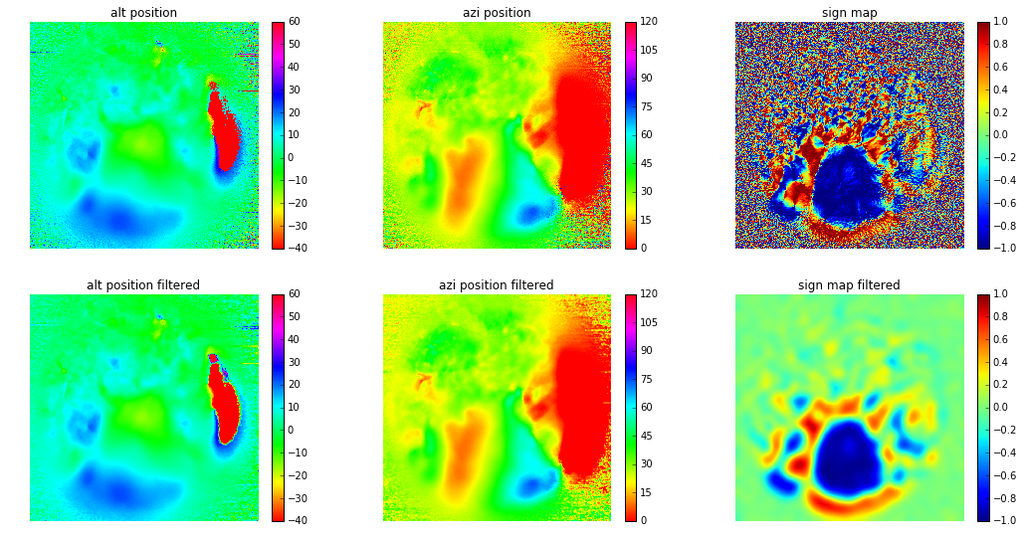

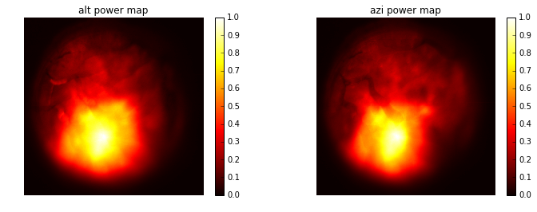

```python
phaseMapFilterSigma = 1.0
signMapFilterSigma = 9.0

getSignMapWidget(trial,
                 phaseMapFilterSigmaDefault=phaseMapFilterSigma,
                 signMapFilterSigmaDefault=signMapFilterSigma,
)
submitAndRunBelowButton()
```

*Get raw patch map*

*signMapThr:*

- Threshold to binarize visual signmap
- FLOAT, default = 0.35, recommended range: [0.2, 0.5]
- Large signMapThr gives you fewer patches
- Smaller signMapThr gives you more patches

*closeIter:*

- Binary close iteration for each raw patches
- INT, default = 3
- You do not want to change this parameter very often

*openIter:*

- Binary open iteration for each raw patches
- INT, default = 3
- You do not want to change this parameter very often

```
signMapThr: 0.35
operIter: 3
closeIter: 3
```

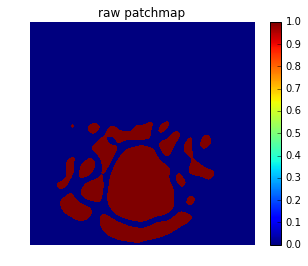

```python
signMapThr = 0.35
openIter = 3
closeIter = 3


getRawPatchMapWidget(trial,
                     signMapThrDefault=signMapThr,
                     openIterDefault=openIter,
                     closeIterDefault=closeIter,
)
submitAndRunBelowButton()
```

*Get dictionary for raw patches*

*dilationIter:*

- Binary dilation iteration for each raw patches
- INT, default = 15
- You do not want to change this parameter very often

*borderWidth:*

- Pixel number between adjcent patches
- INT, default = 1
- You do not want to change this parameter very often

*smallPatchThr:*

- The patches with pixel number below this number will be discarded
- INT, default = 100
- You do not want to change this parameter very often

```
dilationIter: 15
borderWidth: 1
smallPatchThr: 100
```

```
C:\Anaconda\Lib\site-packages\skimage\measure\_label.py:4: skimage_deprecation: Call to deprecated function ``label``. Use ``skimage.measure.label`` instead.
  connectivity=None):
```

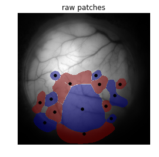

```python
dilationIter = 15
borderWidth = 1
smallPatchThr = 100

getRawPatchesWidget(trial,
                   dilationIterDefault=dilationIter,
                   borderWidthDefault=borderWidth,
                   smallPatchThrDefault=smallPatchThr,
)
submitAndRunBelowButton()
```

*Calculate determinant map*

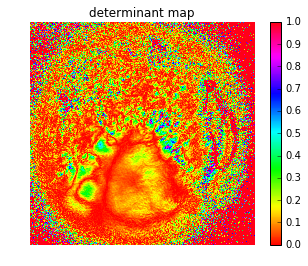

```python
trial.getDeterminantMap()
```

*Calculate eccentricity map*

*eccMapFilterSigma:*

- The sigma value of Gaussian filter for eccentricity maps
- FLOAT, default = 10.0
- You do not want to change this parameter very often, and it may take some time to run

```
eccMapFilterSigma: 10.0
```

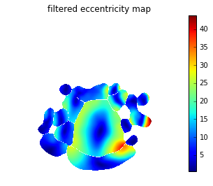

```python
eccMapFilterSigma = 10.0

getEccentricityMapWidget(trial,eccMapFilterSigmaDefault=eccMapFilterSigma)
submitAndRunBelowButton()
```

*Split overlapping patches*

*visualSpacePixelSize:*

- The pixel size for patch to visual space mapping
- FLOAT, default = 0.5
- You do not want to change this parameter very often

*visualSpaceCloseIter:*

- The binary iteration for visual space coverage for each patch
- INT, default = 15
- You do not want to change this parameter very often

*splitLocalMinCutStep:*

- The step width for detecting number of local minimums during spliting
- FLOAT, default = 5.0, recommend range: [0.5, 15.0]
- Small "splitLocalMinCutStep" will make it more likely to split but into less sub patches
- Large "splitLocalMinCutStep" will make it less likely to split but into more sub patches

*splitOverlapThr:*

```
visualSpacePixelSize: 0.5
visualSpaceCloseIter: 15
splitLocalMinCutStep: 5.0
splitOverlapThr: 1.2
patch06 AU=341.5  AS=323.343870016  ratio=0.946834172814
patch02 AU=539.25  AS=567.305854389  ratio=1.05202754639
patch05 AU=426.5  AS=753.544649055  ratio=1.76681043155
2 local minuma were found!!!
patch09 AU=291.25  AS=283.737404358  ratio=0.974205680198
patch08 AU=257.75  AS=285.895086335  ratio=1.10919529131
patch04 AU=240.0  AS=217.201627174  ratio=0.90500677989
patch12 AU=343.5  AS=354.118287077  ratio=1.03091204389
patch13 AU=69.75  AS=70.4139692538  ratio=1.00951927246
patch07 AU=607.5  AS=602.975226153  ratio=0.992551812598
patch11 AU=68.5  AS=65.8968805516  ratio=0.961998256228
patch01 AU=1667.25  AS=1621.03780676  ratio=0.972282385221
patch10 AU=249.0  AS=441.143999918  ratio=1.77166265027
Only one local minumum was found!!!
patch14 AU=46.25  AS=37.2399086633  ratio=0.805187214342
patch03 AU=792.75  AS=847.947282918  ratio=1.06962760381
```

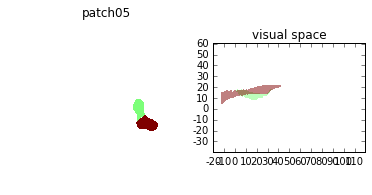

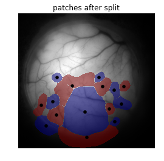

```python
visualSpacePixelSize = 0.5
visualSpaceCloseIter = 15
splitLocalMinCutStep = 5.0
splitOverlapThr = 1.2

splitPatchesWidget(trial,
                   visualSpacePixelSizeDefault=visualSpacePixelSize,
                   visualSpaceCloseIterDefault=visualSpaceCloseIter,
                   splitLocalMinCutStepDefault=splitLocalMinCutStep,
                   splitOverlapThrDefault=splitOverlapThr
)
submitAndRunBelowButton()
```

*Merge non-overlapping patches*

*mergeOverlapThr:*

- Considering a patch pair (A and B) with same sign, A has visual coverage a deg<sup>2</sup> and B has visual coverage b deg<sup>2</sup>
- The overlaping visual coverage between this pair is c deg<sup>2</sup>
- Then if (c/a < "mergeOverlapThr") and (c/b < "mergeOverlapThr"), these two patches will be merged
- FLOAT, default = 0.1, recommend range: [0.0, 0.2], should be smaller than 1.0
- Small "mergeOverlapThr" will merge less patches
- Large "mergeOverlapThr" will merge more patches

```
mergeOverlapThr: 0.1
merge iteration: 1
```

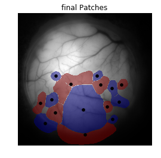

```python
mergeOverlapThr = 0.1

mergePatchesWidget(trial,mergeOverlapThrDefault=mergeOverlapThr)
submitAndRunBelowButton()
```

*Rename patches*

- Click the patches and type their desired names according to the reference map below
- Established visual area names:
- A, AL, AM, LI, LLA, LM, M, MMA, MMP, P, PM, POR, RL, RLL, RS, S1, V1
- The name you typed within this list will show in green, others will show in orange

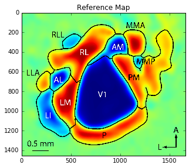

```python
patchplot_widgets = PatchPlotWidgets(trial,{},[],figsize=(5,5))
patchplot_widgets.plot_reference_img()
```

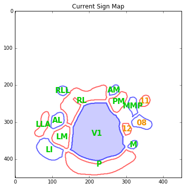

```python
rename_patches_dict = dict(trial.finalPatches)

DESIRED_PATCH_NAMES = ['A','AL','AM','LI','LLA','LM','M','MMA','MMP','P','PM','POR','RL','RLL','RS','S1','V1']

for patch in rename_patches_dict.keys(): #replace 'patch01' with 01, etc
    rename_patches_dict[patch.replace("patch","")] = rename_patches_dict.pop(patch)
patchplot_widgets = PatchPlotWidgets(trial,rename_patches_dict,DESIRED_PATCH_NAMES,figsize=(12,6))

patchplot_widgets.show()
submitAndRunBelowButton()
```

*Plot final borders*

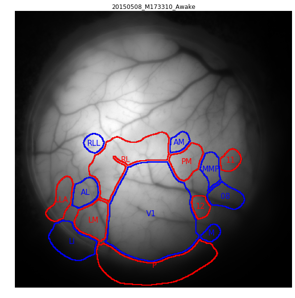

```python
rename_patches_dict = patchplot_widgets.patches_dict
finalPatchBorder_figure = trial.plotFinalPatchBorders(rename_patches_dict,borderWidth=4)
#trial.params["finalPatchesMarked"] = rename_patches_dict
#trial.finalPatchesMarked = rename_patches_dict
```

*Save*

- Saves the following to the directory containing the original pkl file:
- final borders plot (.png & .pdf)
- updated pkl file
- the current notebook (.ipynb & .html)

```python
pkl_save_path = None
#saveTrialDictPkl(trial,pkl_save_path)
saveFinalResultWidget(trial,finalPatchBorder_figure,__pkl_path,pkl_save_path,avoid_overwrite=(not _TEST_PKL_USED))
```